# PCIT-CoS-Waitlist RCT Paper 1: CCQ Caregiving Helplessness

Nancy Briggs

2024-04-29

### CCQ Caregiving Helplessness

Output run on 2024-04-29

Values are totals, not means, of the following CCQ variables: CCQD1, CCQD2, CCQD3, CCQD4, CCQD5, CCQD6, CCQD7

#### Descriptives

| group | time | n | mean | sd | median | min | max |
| --- | --- | --- | --- | --- | --- | --- | --- |
| 1 | 1 | 30 | 13.000 | 5.571 | 12.0 | 7 | 33.000 |
| 1 | 2 | 22 | 10.727 | 5.556 | 8.0 | 7 | 29.000 |
| 1 | 3 | 18 | 11.000 | 6.633 | 8.5 | 7 | 35.000 |
| 2 | 1 | 28 | 15.761 | 6.244 | 16.5 | 7 | 30.800 |
| 2 | 2 | 13 | 13.615 | 4.857 | 13.0 | 8 | 25.000 |
| 2 | 3 | 5 | 10.267 | 4.206 | 8.0 | 7 | 16.333 |
| 3 | 1 | 25 | 13.680 | 5.313 | 14.0 | 7 | 24.000 |
| 3 | 2 | 22 | 11.689 | 3.363 | 11.0 | 7 | 19.000 |
| 3 | 3 | 0 | NaN | NA | NA | Inf | -Inf |

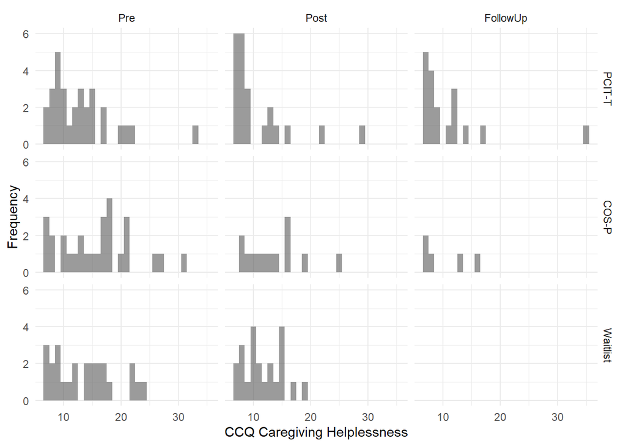

#### Model & Results

A linear mixed model with random effect for individual and fixed effects of group, time and the interaction was run. Estimated marginal means were obtained, and contrasts specified to test Hypothesis 1 and Hypothesis 2.

```
## fixed-effect model matrix is rank deficient so dropping 1 column / coefficient
```

This is the ANOVA table for the model. p-values are likelihood ratio tests for adding the new term to the model just before. A p-value <0.05 indicates that adding that term results in better model fit. The most important p-value is the interaction p-value.

```
## refitting model(s) with ML (instead of REML)
```

|  | Effect | npar | AIC | BIC | logLik | deviance | Chisq | Df | Pr(>Chisq) |
| --- | --- | --- | --- | --- | --- | --- | --- | --- | --- |
| result0 | Intercept | 3 | 978.936 | 988.217 | -486.468 | 972.936 | NA | NA | NA |
| result1 | Group | 5 | 977.569 | 993.038 | -483.785 | 967.569 | 5.366 | 2 | 0.068 |
| result2 | Time | 7 | 963.465 | 985.121 | -474.732 | 949.465 | 18.104 | 2 | 0.000 |
| result3 | Group*Time | 10 | 968.824 | 999.762 | -474.412 | 948.824 | 0.640 | 3 | 0.887 |

Here, there is no evidence that the pattern of change over time is different between the groups (0.8871).

```r
summary(result3)
```

```
## Linear mixed model fit by REML. t-tests use Satterthwaite's method [
## lmerModLmerTest]
## Formula: outcome ~ group * time + (1 | id)
##    Data: dat
##
## REML criterion at convergence: 934.1
##
## Scaled residuals:
##      Min       1Q   Median       3Q      Max
## -1.44355 -0.50410 -0.06672  0.38912  2.31076
##
## Random effects:
##  Groups   Name        Variance Std.Dev.
##  id       (Intercept) 19.277   4.391
##  Residual              9.227   3.038
## Number of obs: 163, groups:  id, 85
##
## Fixed effects:
##              Estimate Std. Error       df t value Pr(>|t|)
## (Intercept)   13.0000     0.9747 108.2959  13.337   <2e-16 ***
## group2         2.7607     1.4029 108.2959   1.968   0.0516 .
## group3         0.5301     1.4325 111.2853   0.370   0.7120
## time2         -1.8923     0.8931  82.2358  -2.119   0.0371 *
## time3         -2.0411     0.9637  83.0613  -2.118   0.0372 *
## group2:time2  -0.8207     1.4471  86.9470  -0.567   0.5721
## group3:time2  -0.3681     1.2934  83.0378  -0.285   0.7767
## group2:time3  -1.3516     1.9542  87.4616  -0.692   0.4910
## ---
## Signif. codes:  0 '***' 0.001 '**' 0.01 '*' 0.05 '.' 0.1 ' ' 1
##
## Correlation of Fixed Effects:
##             (Intr) group2 group3 time2  time3  grp2:2 grp3:2
## group2      -0.695
## group3      -0.680  0.473
## time2       -0.353  0.245  0.240
## time3       -0.327  0.227  0.223  0.428
## group2:tim2  0.218 -0.314 -0.148 -0.617 -0.264
## group3:tim2  0.244 -0.170 -0.379 -0.691 -0.295  0.426
## group2:tim3  0.161 -0.232 -0.110 -0.211 -0.493  0.338  0.146
## fit warnings:
## fixed-effect model matrix is rank deficient so dropping 1 column / coefficient
```

#### Estimated Means & Change

Estimated means for each Treatment and Time are presented. In addition, within-group change between time points is presented with 95% CIs.

##### Group mean difference at each timepoint

Effect sizes all calculated by the pooled T1 SD of the outcome. Adjusted p-value from Bonferroni correction.

Group Differences at Each Time Point

| Group Difference | Time | Mean | SE | t | p | adj p | Lower CL | Upper CL | Effect Size | Lower CL | Upper CL |
| --- | --- | --- | --- | --- | --- | --- | --- | --- | --- | --- | --- |
| 1 - 2 | 1 | -2.761 | 1.403 | -1.968 | 0.125 | 0.155 | -6.096 | 0.574 | -0.468 | -1.084 | -0.003 |
| 1 - 3 | 1 | -0.530 | 1.433 | -0.370 | 0.927 | 1.000 | -3.935 | 2.874 | -0.090 | -0.595 | 0.403 |
| 2 - 3 | 1 | 2.231 | 1.456 | 1.532 | 0.280 | 0.385 | -1.230 | 5.691 | 0.378 | -0.126 | 0.917 |
| 1 - 2 | 2 | -1.940 | 1.673 | -1.159 | 0.479 | 0.745 | -5.903 | 2.023 | -0.329 | -1.086 | 0.301 |
| 1 - 3 | 2 | -0.162 | 1.525 | -0.106 | 0.994 | 1.000 | -3.778 | 3.454 | -0.027 | -0.623 | 0.509 |
| 2 - 3 | 2 | 1.778 | 1.689 | 1.052 | 0.545 | 0.883 | -2.223 | 5.779 | 0.301 | -0.293 | 0.998 |
| 1 - 2 | 3 | -1.409 | 2.130 | -0.661 | 0.786 | 1.000 | -6.452 | 3.634 | -0.239 | -1.074 | 0.523 |
| 1 - 3 | 3 | NA | NA | NA | NA | NA | NA | NA | NA | NA | NA |
| 2 - 3 | 3 | NA | NA | NA | NA | NA | NA | NA | NA | NA | NA |

* Effect size scaled by pooled T1 SD  
† ES 95% Bootstrapped Percentile CI limits  
‡ If you want a positive ES (and it is calculated as negative), be sure to switch the signs and positions of the lower and upper CIs.

##### Change within each group

Within-Group Change and Effect Sizes

| Change | Group | Mean | SE | t | p | adj p | Lower CL | Upper CL | Effect Size | Lower CL | Upper CL |
| --- | --- | --- | --- | --- | --- | --- | --- | --- | --- | --- | --- |
| 1 - 2 | 1 | 1.892 | 0.895 | 2.115 | 0.093 | 0.113 | -0.244 | 4.029 | 0.320 | 0.045 | 0.706 |
| 1 - 3 | 1 | 2.041 | 0.966 | 2.114 | 0.093 | 0.113 | -0.265 | 4.347 | 0.346 | 0.031 | 0.780 |
| 2 - 3 | 1 | 0.149 | 0.996 | 0.149 | 0.988 | 1.000 | -2.232 | 2.530 | 0.025 | -0.337 | 0.411 |
| 1 - 2 | 2 | 2.713 | 1.143 | 2.374 | 0.051 | 0.059 | -0.012 | 5.438 | 0.459 | 0.127 | 0.953 |
| 1 - 3 | 2 | 3.393 | 1.706 | 1.988 | 0.121 | 0.150 | -0.677 | 7.463 | 0.575 | 0.051 | 1.227 |
| 2 - 3 | 2 | 0.680 | 1.739 | 0.391 | 0.919 | 1.000 | -3.474 | 4.834 | 0.115 | -0.413 | 0.737 |
| 1 - 2 | 3 | 2.260 | 0.937 | 2.412 | 0.047 | 0.054 | 0.022 | 4.498 | 0.383 | 0.066 | 0.822 |
| 1 - 3 | 3 | NA | NA | NA | NA | NA | NA | NA | NA | NA | NA |
| 2 - 3 | 3 | NA | NA | NA | NA | NA | NA | NA | NA | NA | NA |

* Effect size scaled by pooled T1 SD  
† ES 95% Bootstrapped Percentile CI limits  
‡ If you want a positive ES (and it is calculated as negative), be sure to switch the signs and positions of the lower and upper CIs.

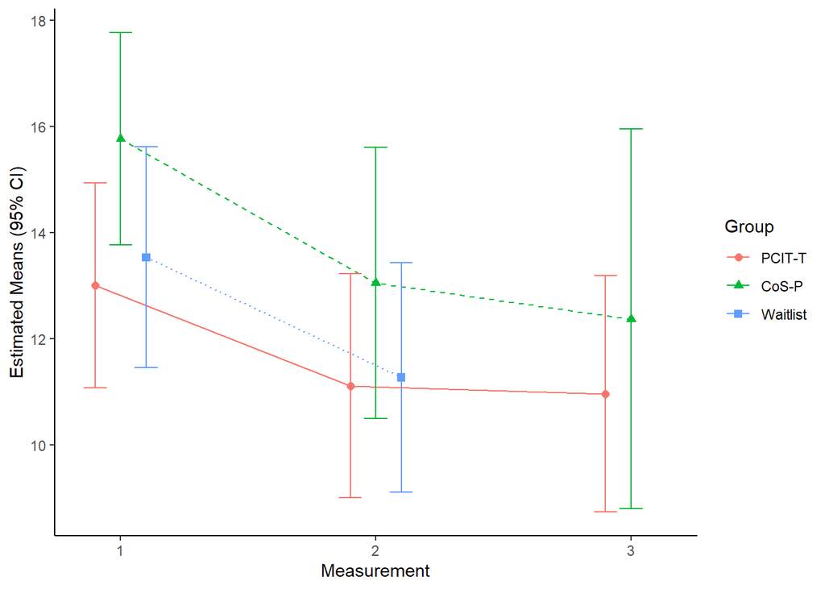

#### Hypothesis 1

We hypothesize that from baseline (‘T1’) to post-treatment/waitlist (‘T2’) there will be a gradient effect, whereby parent-child dyads who receive PCIT-T will show the greatest gains and parent-child dyads who receive no treatment will show the least gains. For the outcome, then, the null hypothesis is:

$H_0: \text {mean change}(\text{PCIT-T}) = \text {mean change}(\text{CoS-P}) = \text {mean change}(\text{Waitlist})$ $H_A: \text {mean change}(\text{PCIT-T}) > \text {mean change}(\text{CoS-P}) > \text {mean change}(\text{Waitlist})$

This is a joint hypothesis test.

First, confirming that the ordering of the means is as hypothesized:

```
## group = 1:
##  contrast estimate    SE   df t.ratio p.value
##  1 - 2       1.892 0.895 79.2   2.115  0.0932
##  1 - 3       2.041 0.966 80.0   2.114  0.0934
##  2 - 3       0.149 0.996 76.0   0.149  0.9878
##
## group = 2:
##  contrast estimate    SE   df t.ratio p.value
##  1 - 2       2.713 1.143 86.9   2.374  0.0513
##  1 - 3       3.393 1.706 85.9   1.988  0.1212
##  2 - 3       0.680 1.739 79.5   0.391  0.9193
##
## group = 3:
##  contrast estimate    SE   df t.ratio p.value
##  1 - 2       2.260 0.937 80.7   2.412  0.0472
##  1 - 3      nonEst    NA   NA      NA      NA
##  2 - 3      nonEst    NA   NA      NA      NA
##
## Degrees-of-freedom method: kenward-roger
## P value adjustment: tukey method for comparing a family of 3 estimates
```

| contrast | group | t1t2change | quality | p.value |
| --- | --- | --- | --- | --- |
| 1 - 2 | 1 | -1.892 | decreased t1 to t2 | 0.093 |
| 1 - 2 | 2 | -2.713 | decreased t1 to t2 | 0.051 |
| 1 - 2 | 3 | -2.260 | decreased t1 to t2 | 0.047 |

Is the ordering of change satisfied?

Greatest to least change from t1 to t2: Order not satisfied

Note that I interpreted an increase in scores as being “better”. If a decrease in scores is “better” then these change values should be interpreted in that light.

```
##   (Intercept) group2 group3 time2 time3 group2:time2 group3:time2 group2:time3
## 1           0      0      0     0     0            1            0            0
## 2           0      0      0     0     0           -1            1            0
```

```
##
##   General Linear Hypotheses
##
## Linear Hypotheses:
##        Estimate
## 1 == 0  -0.8207
## 2 == 0   0.4525
##
## Global Test:
##        F DF1 DF2 Pr(>F)
## 1 0.1619   2 153 0.8507
```

p= 0.851. We have no evidence that there is a difference in the change over from Baseline to Post amongst the groups.

#### Hypothesis 2

##### Change from T2-T3

There will be a gradient of size of change from T2 to T3 such that the change in the PCIT-T group > the change in the CoS-P group. This isn’t really a gradient; it’s just 1 hypothesis.

First, the change in PCITT and COSP from time 2 to time 3:

```
## group = 1:
##  time emmean    SE  df lower.CL upper.CL
##  1      13.0 0.975 106    11.07     14.9
##  2      11.1 1.065 129     9.00     13.2
##  3      11.0 1.126 141     8.73     13.2
##
## group = 2:
##  time emmean    SE  df lower.CL upper.CL
##  1      15.8 1.009 106    13.76     17.8
##  2      13.0 1.290 152    10.50     15.6
##  3      12.4 1.809 136     8.79     15.9
##
## group = 3:
##  time emmean    SE  df lower.CL upper.CL
##  1      13.5 1.050 111    11.45     15.6
##  2      11.3 1.090 121     9.11     13.4
##  3    nonEst    NA  NA       NA       NA
##
## Degrees-of-freedom method: kenward-roger
## Confidence level used: 0.95
```

```
## group = 1:
##  contrast estimate    SE   df lower.CL upper.CL
##  1 - 2       1.892 0.895 79.2  -0.2444     4.03
##  1 - 3       2.041 0.966 80.0  -0.2648     4.35
##  2 - 3       0.149 0.996 76.0  -2.2321     2.53
##
## group = 2:
##  contrast estimate    SE   df lower.CL upper.CL
##  1 - 2       2.713 1.143 86.9  -0.0121     5.44
##  1 - 3       3.393 1.706 85.9  -0.6771     7.46
##  2 - 3       0.680 1.739 79.5  -3.4745     4.83
##
## group = 3:
##  contrast estimate    SE   df lower.CL upper.CL
##  1 - 2       2.260 0.937 80.7   0.0224     4.50
##  1 - 3      nonEst    NA   NA       NA       NA
##  2 - 3      nonEst    NA   NA       NA       NA
##
## Degrees-of-freedom method: kenward-roger
## Confidence level used: 0.95
## Conf-level adjustment: tukey method for comparing a family of 3 estimates
```

```r
## Specify contrast matrices
# Hyp1 is 1 df test
# could use alternative="less" ir alternative="greater" in glht
hyp2   <- matrix(c(0, 0,0, 0,0, -1,0,1 ),1)
hyp2F <- glht(result3, linfct = hyp2)
summary(hyp2F)
```

```
##
##   Simultaneous Tests for General Linear Hypotheses
##
## Fit: lmer(formula = outcome ~ group * time + (1 | id), data = dat)
##
## Linear Hypotheses:
##        Estimate Std. Error z value Pr(>|z|)
## 1 == 0   -0.531      2.001  -0.265    0.791
## (Adjusted p values reported -- single-step method)
```

```r
s<-summary(hyp2F, test = Ftest())
#also see this webpage for more on contrasts https://rcompanion.org/rcompanion/h_01.html



## Extract pvaue for evidence / no evidence
evidence = ifelse(s$test$pvalue<0.05, "evidence", "no evidence")
```

Change in G1 from T2 to T3: 0.149

Change in G2 from T2 to T3: 0.68

##### Change from T1-T3

```
##
##   General Linear Hypotheses
##
## Linear Hypotheses:
##        Estimate
## 1 == 0   -1.352
##
## Global Test:
##        F DF1 DF2 Pr(>F)
## 1 0.4784   1 153 0.4902
```

Change in G1 from T1 to T3: 2.041

Change in G2 from T1 to T3: 3.393

p=0.4902. We have no evidence that the change from T1 to T3 is different for G1 and G2

#### Residuals

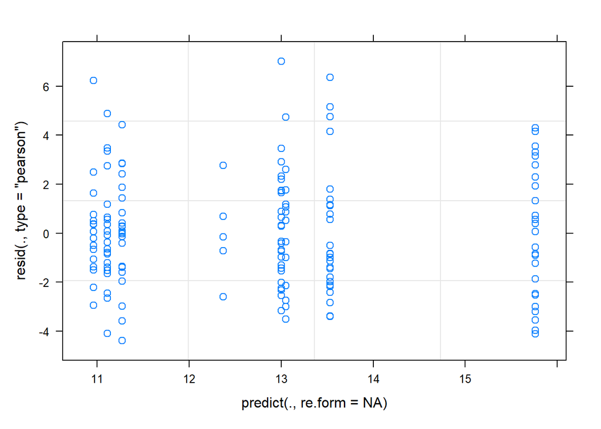

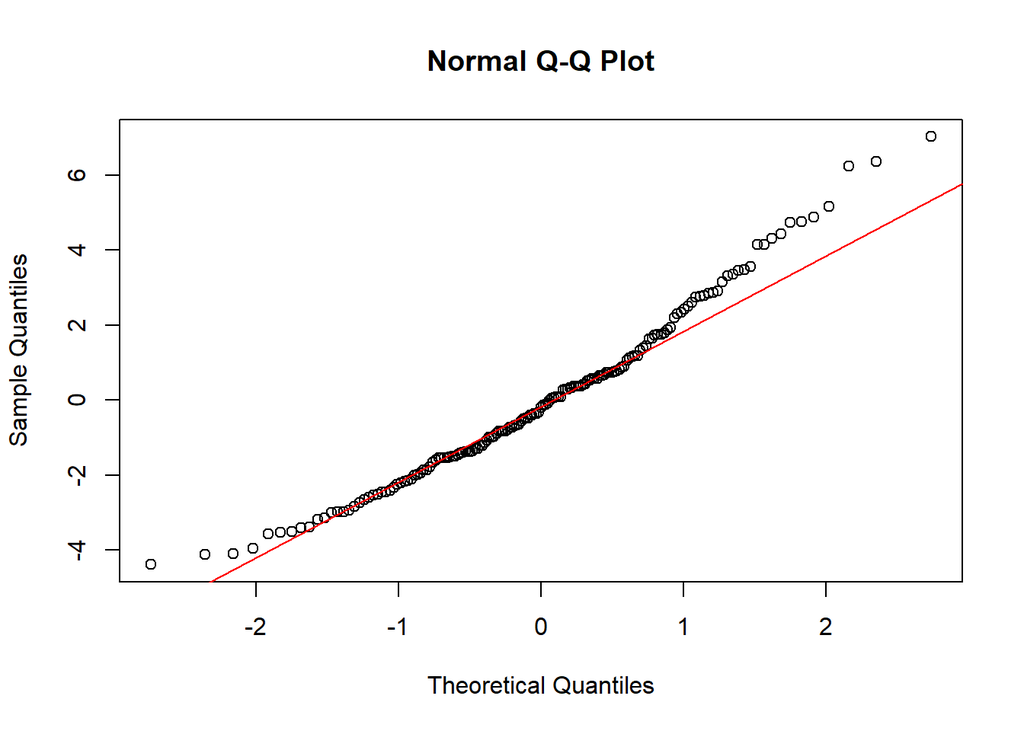

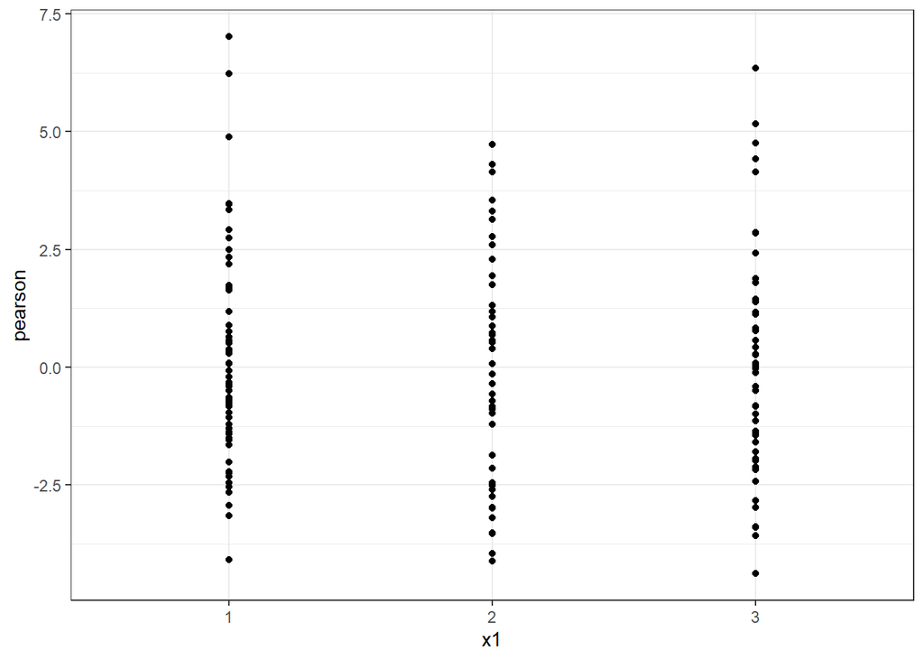

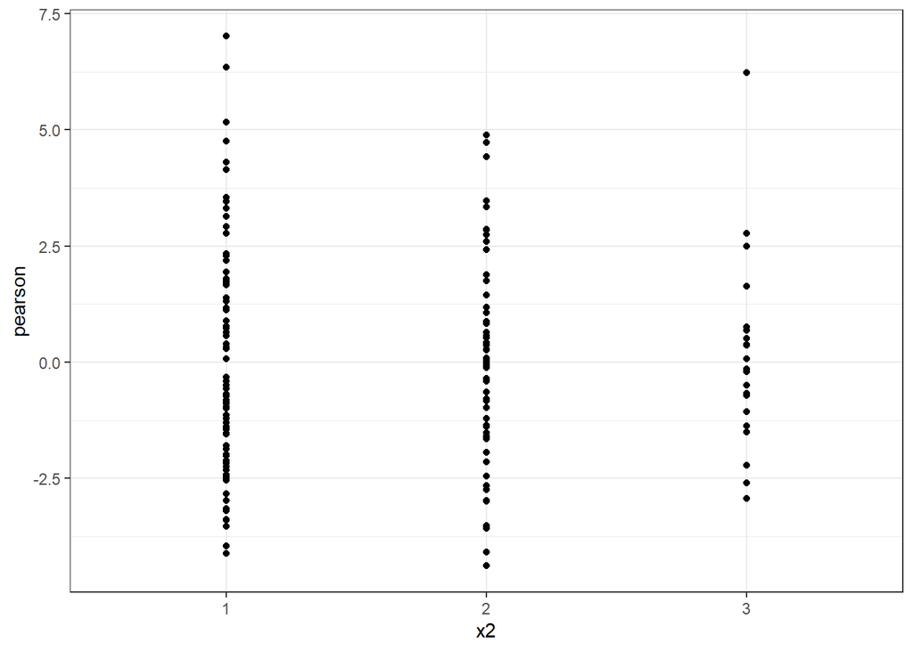

```r
rm(list = ls())
```